# MultiGWAS report for Naive GWAS model

This report, created by the MultiGWAS tool, is a summary of the input parameters used to run the tool and its main outputs. The outputs include the best-ranked and significative SNPs found for each tool. For each one, there is a score table, Venn diagram, and an SNP profile.

# 1 Input Parameters

MultiGWAS uses as input a configuration file where the user specifies the input genomic data (genotype and phenotype files) along with different values for parameters used by the MultiGWAS tool and by the other four GWAS software (GWASpoly, SHEsis, PLINK, and TASSEL).

The following table shows the current input parameters specified by the user in the configuration file:

| PARAMETER | VALUE |
| --- | --- |
| Ploidy (4 or 2) | 4 |
| Genotype filename | example-genotype-tetra.csv |
| Phenotype filename | example-phenotype.csv |
| Significance level (Genome-wide significance level) | 0.05 |
| Correction method (Bonferroni or FDR) | Bonferroni |
| GWAS model (Full or Naive) | Naive |
| nBest (Number of best-ranked SNPs to be reported) | 8 |
| Filtering (TRUE or FALSE) | TRUE |
| MIND Filter (Individual with missing genotype) | 0.1 |
| GENO Filter (SNPs with missing genotype) | 0.1 |
| MAF Filter (Minor allele frequency) | 0.01 |
| HWE Filter (Hardy-Weinberg test) | 1e-10 |
| GWAS Tools | GWASpoly SHEsis PLINK TASSEL |

# 2 Best-ranked SNPs

This section shows a table and a Venn diagram for the best ranked SNPs (For this report, N=8). The configuration file allows defining the parameter N.

## 2.1 Table of best-ranked SNPs

The following table shows the associations between SNPs and the trait as transformed p-values to scores as -log 10 (p-value) sorted from the highest to the lowest scores based on each tool analysis and the model selected (Full or Naive). Each SNP has its associated information, such as the chromosome, position in the genome, and name. Also, based on the threshold calculated by a multiple testing correction (i.e., Bonferroni or FDR), the table marks the significance of each SNP as a TRUE or FALSE.

| TOOL | MODEL | GC | SNP | CHROM | POSITION | PVALUE | SCORE | THRESHOLD | SIGNIFICANCE |
| --- | --- | --- | --- | --- | --- | --- | --- | --- | --- |
| GWASpoly | diplo-general | 1.074 | c2_9925 | 1 | 81410256 | 0.001698 | 2.7700 | 4.3300 | FALSE |
| GWASpoly | diplo-general | 1.074 | c2_25250 | 7 | 47642053 | 0.002089 | 2.6800 | 4.3300 | FALSE |
| GWASpoly | diplo-general | 1.074 | c2_4045 | 9 | 3710627 | 0.002692 | 2.5700 | 4.3300 | FALSE |
| GWASpoly | diplo-general | 1.074 | c2_33635 | 11 | 2362124 | 0.002692 | 2.5700 | 4.3300 | FALSE |
| GWASpoly | diplo-general | 1.074 | c2_16999 | 8 | 54838024 | 0.003311 | 2.4800 | 4.3300 | FALSE |
| GWASpoly | diplo-general | 1.074 | c2_37638 | 11 | 4553298 | 0.003981 | 2.4000 | 4.3300 | FALSE |
| GWASpoly | diplo-general | 1.074 | c1_5126 | 7 | 43253894 | 0.004074 | 2.3900 | 4.3300 | FALSE |
| GWASpoly | diplo-general | 1.074 | c2_34557 | 7 | 26752660 | 0.005495 | 2.2600 | 4.3300 | FALSE |
| PLINK | additive | 5.698 | c2_11977 | 5 | 3515956 | 0.000000 | 11.7562 | 4.3852 | TRUE |
| PLINK | additive | 5.698 | c2_47760 | 2 | 20034673 | 0.000000 | 10.8921 | 4.3852 | TRUE |
| PLINK | additive | 5.698 | c2_30171 | 2 | 19605917 | 0.000000 | 10.6189 | 4.3852 | TRUE |
| PLINK | additive | 5.698 | c1_211 | 9 | 36041036 | 0.000000 | 8.6801 | 4.3852 | TRUE |
| PLINK | additive | 5.698 | c2_2943 | 2 | 17206059 | 0.000000 | 8.3332 | 4.3852 | TRUE |
| PLINK | additive | 5.698 | c2_16350 | 2 | 14356716 | 0.000000 | 8.0681 | 4.3852 | TRUE |
| PLINK | additive | 5.698 | c2_3021 | 9 | 58582477 | 0.000000 | 8.0200 | 4.3852 | TRUE |
| PLINK | additive | 5.698 | c2_35165 | 2 | 37982843 | 0.000000 | 7.9923 | 4.3852 | TRUE |
| SHEsis | general | 6.127 | c2_47760 | 2 | 20034673 | 0.000000 | 14.2757 | 4.3852 | TRUE |
| SHEsis | general | 6.127 | c2_30171 | 2 | 19605917 | 0.000000 | 13.2882 | 4.3852 | TRUE |
| SHEsis | general | 6.127 | c2_53380 | 1 | 70371898 | 0.000000 | 12.2857 | 4.3852 | TRUE |
| SHEsis | general | 6.127 | c2_16350 | 2 | 14356716 | 0.000000 | 9.9914 | 4.3852 | TRUE |
| SHEsis | general | 6.127 | c2_2943 | 2 | 17206059 | 0.000000 | 9.2328 | 4.3852 | TRUE |
| SHEsis | general | 6.127 | c1_211 | 9 | 36041036 | 0.000000 | 9.1409 | 4.3852 | TRUE |
| SHEsis | general | 6.127 | c1_8347 | 4 | 9523778 | 0.000000 | 9.0975 | 4.3852 | TRUE |
| SHEsis | general | 6.127 | c2_26793 | 4 | 9524196 | 0.000000 | 9.0975 | 4.3852 | TRUE |
| TASSEL | dominant | 1.276 | c2_3021 | 9 | 58582477 | 0.007710 | 2.1129 | 3.4800 | FALSE |
| TASSEL | dominant | 1.276 | c1_14778 | 6 | 7467662 | 0.026070 | 1.5839 | 3.4800 | FALSE |
| TASSEL | dominant | 1.276 | c1_1426 | 9 | 4373995 | 0.026920 | 1.5699 | 3.4800 | FALSE |
| TASSEL | dominant | 1.276 | c2_10566 | 4 | 71954636 | 0.043620 | 1.3603 | 3.4800 | FALSE |
| TASSEL | dominant | 1.276 | c2_50301 | 5 | 5055948 | 0.048570 | 1.3136 | 3.4800 | FALSE |
| TASSEL | dominant | 1.276 | c2_2653 | 1 | 58737722 | 0.051400 | 1.2890 | 3.4800 | FALSE |
| TASSEL | dominant | 1.276 | c2_23250 | 12 | 53642804 | 0.070000 | 1.1549 | 3.4800 | FALSE |
| TASSEL | dominant | 1.276 | c2_23320 | 12 | 53052450 | 0.074280 | 1.1291 | 3.4800 | FALSE |

## 2.2 Venn diagram of best-ranked SNPs

The Venn diagram shows the best-ranked SNPs with high scores that are either unique or shared by the four software. Shared SNPs appear in the intersection areas of the diagram.

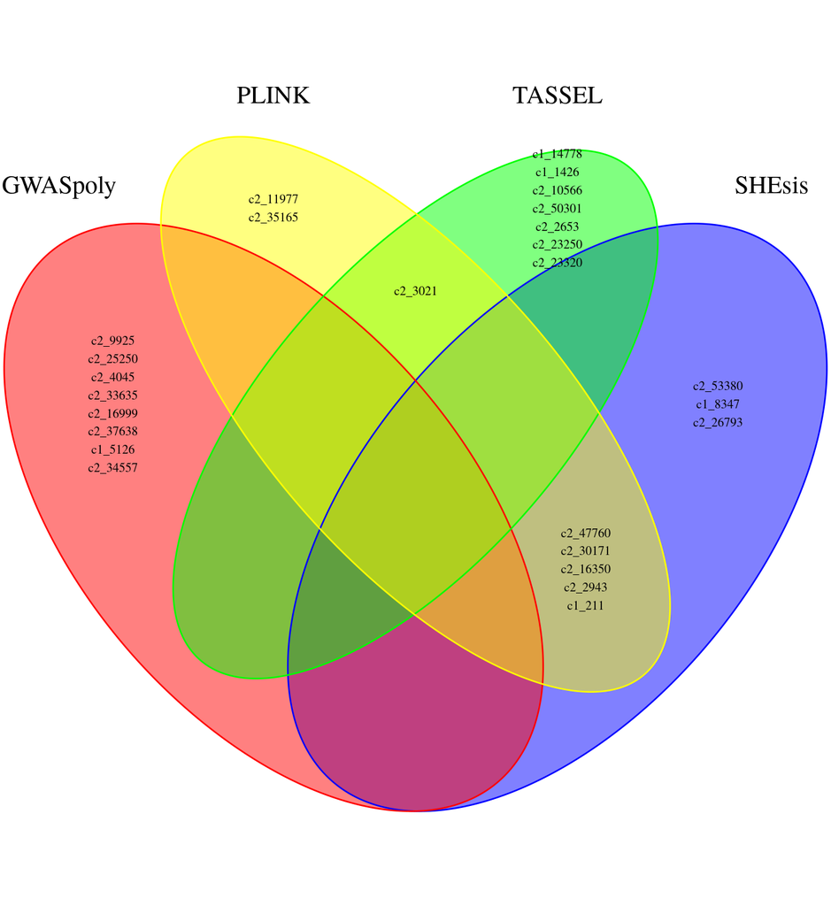

# 3 Significative SNPs

This section shows a table and a Venn diagram for the signifcative SNPs (score is above the significance threshold for each tool).

## 3.1 Table of significative SNPs

The following table shows the associations between SNPs and the trait as transformed p-values to scores as -log 10 (p-value) sorted from the highest to the lowest scores based on each tool analysis and the model selected (Full or Naive). Each SNP has its associated information, such as the chromosome, position in the genome, and name.

| TOOL | MODEL | GC | SNP | CHROM | POSITION | PVALUE | SCORE | THRESHOLD | SIGNIFICANCE |
| --- | --- | --- | --- | --- | --- | --- | --- | --- | --- |
| PLINK | additive | 5.698 | c2_11977 | 5 | 3515956 | 0 | 11.7562 | 4.3852 | TRUE |
| PLINK | additive | 5.698 | c2_47760 | 2 | 20034673 | 0 | 10.8921 | 4.3852 | TRUE |
| PLINK | additive | 5.698 | c2_30171 | 2 | 19605917 | 0 | 10.6189 | 4.3852 | TRUE |
| PLINK | additive | 5.698 | c1_211 | 9 | 36041036 | 0 | 8.6801 | 4.3852 | TRUE |
| PLINK | additive | 5.698 | c2_2943 | 2 | 17206059 | 0 | 8.3332 | 4.3852 | TRUE |
| PLINK | additive | 5.698 | c2_16350 | 2 | 14356716 | 0 | 8.0681 | 4.3852 | TRUE |
| PLINK | additive | 5.698 | c2_3021 | 9 | 58582477 | 0 | 8.0200 | 4.3852 | TRUE |
| PLINK | additive | 5.698 | c2_35165 | 2 | 37982843 | 0 | 7.9923 | 4.3852 | TRUE |
| SHEsis | general | 6.127 | c2_47760 | 2 | 20034673 | 0 | 14.2757 | 4.3852 | TRUE |
| SHEsis | general | 6.127 | c2_30171 | 2 | 19605917 | 0 | 13.2882 | 4.3852 | TRUE |
| SHEsis | general | 6.127 | c2_53380 | 1 | 70371898 | 0 | 12.2857 | 4.3852 | TRUE |
| SHEsis | general | 6.127 | c2_16350 | 2 | 14356716 | 0 | 9.9914 | 4.3852 | TRUE |
| SHEsis | general | 6.127 | c2_2943 | 2 | 17206059 | 0 | 9.2328 | 4.3852 | TRUE |
| SHEsis | general | 6.127 | c1_211 | 9 | 36041036 | 0 | 9.1409 | 4.3852 | TRUE |
| SHEsis | general | 6.127 | c1_8347 | 4 | 9523778 | 0 | 9.0975 | 4.3852 | TRUE |
| SHEsis | general | 6.127 | c2_26793 | 4 | 9524196 | 0 | 9.0975 | 4.3852 | TRUE |

## 3.2 Venn diagram of significative SNPs

The Venn diagram shows the significative SNPs that are either unique or shared by the four software. Shared SNPs appear in the intersection areas of the diagram.

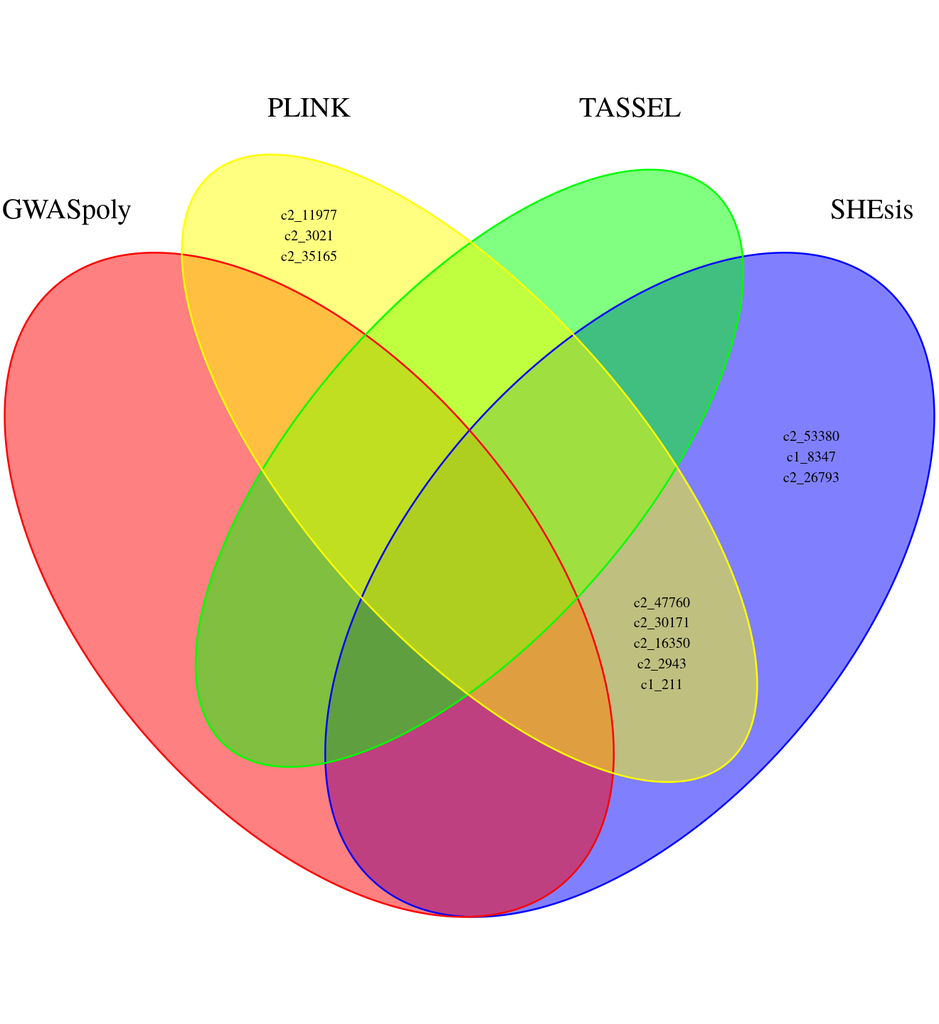

# 4 Manhattan and QQ plots

The QQ plot plots the observed (black dot lines) vs. expected -log 10 (p-value) (red line).

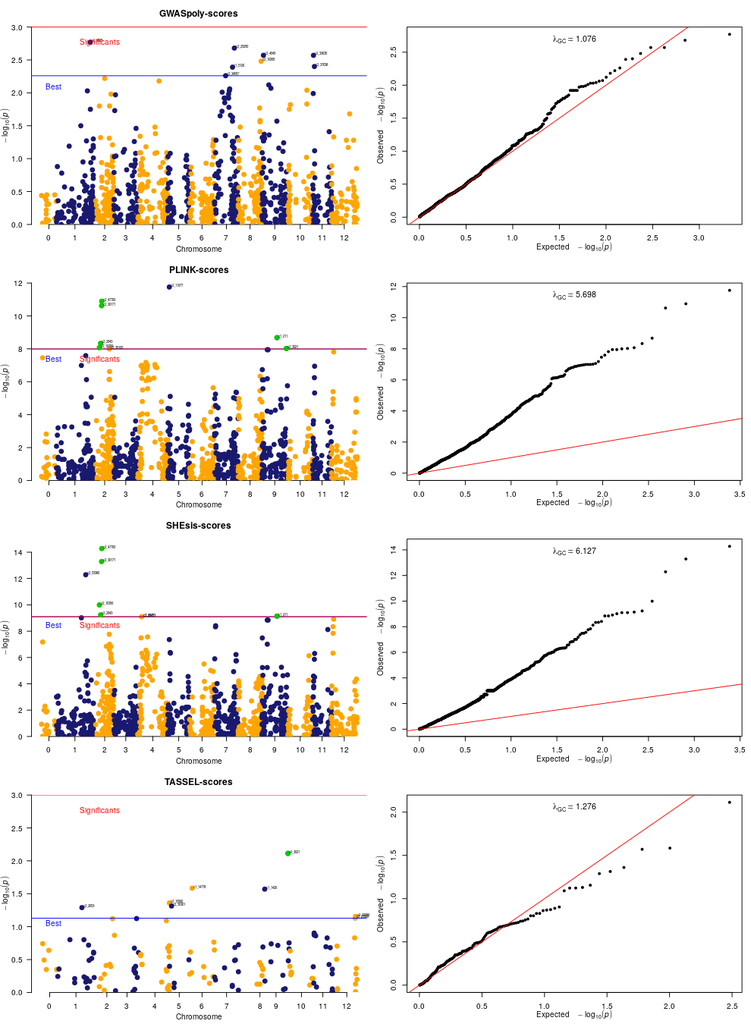